# Trump Tweet Text Analysis

Pascal Niggemeier

24.06.2019

Für die Dokumentation des Projekts wird eine R-Markdown Datei gewählt, weil sie das Reproduzieren des Projektes und der Ergebnisse für den Leser vereinfacht. Für die Präsentation der Ergebnisse liegt eine separate PowerPoint-Präsentation vor.

Der nachfolgende Code-Chunk lädt die benötigten Packages und die Textdaten von Twitter.

```r
if(!require('tidyverse')){
  install.packages('tidyverse')}; library('tidyverse')
if(!require('tidytext')){
  install.packages('tidytext')}; library('tidytext')
if(!require('textdata')){
  install.packages('textdata')}; library('textdata')
if(!require('syuzhet')){
  install.packages('syuzhet')}; library('syuzhet')
if(!require('lubridate')){
  install.packages('lubridate')}; library('lubridate')
if(!require('topicmodels')){
  install.packages('topicmodels')}; library('topicmodels')
if(!require('jsonlite')){
  install.packages('jsonlite')}; library('jsonlite')
if(!require('scales')){
  install.packages('scales')}; library('scales')
tweets <- as.tbl( fromJSON('src/tweets-2019-06-22.json') )
```

# 1 Einleitung: Text-Mining am Beispiel der Twitter Posts von Donald Trump

Das Thema wurde für die Ausarbeitung, neben anderen Punkten, aufgrund des Unterhaltungswert der Projektauslegung auf der einen Seite und der Möglichkeit neue Methoden kennen zu lernen, gewählt.

Es soll die Hypothese von Todd Vaziri bestätigt werden. Es gibt dazu bereits zahlreiche Untersuchungen, jedoch wird es in dieser Ausarbeitung mit einigen neuen Akzenten nachvollzogen. Die Analyse wird dabei strukturiert anhand des *Tidy-Data*-Prinzips und zugehörigem Prozess durchgeführt. Sie soll helfen, die Frage nach der Erkennbarkeit der Stimmungslage (Sentiment) in einzelnen Tweets und über die Zeit zu beantworten. Zudem wird nach einer geeigneten Methode für das automatische Erkennen von Themen innerhalb von Texten gesucht.

Die Ausarbeitung legt ihren Schwerpunkt auf die Analyse der Themen mit denen sich der Twitter account *@realDonaldTrump* befasst, also Topic modeling - Themenanalyse. Daher wird dieses Kapitel etwas ausführlicher ausgelegt. Somit soll die intensive Auseinandersetzung mit der verwendeten Methode sichergestellt werden.

# 2 Grundlagen: Textanalyse und Text-Mining mit R

Im Folgenden soll ein Einstieg in die Textanalyse mit R geboten werden. Die Inhalte bieten die Grundlage für das eigentliche Projekt *“Eine Analyse der Tweets von Donals Trump”*, alias [@realDonaldTrump](https://twitter.com/realdonaldtrump).

## 2.1 Preprocessing & Exploration

*tidy data*-Prinzipien

Das *‘Säubern’* der Textdaten

Ausgangspunkt ist der Text-Mining-Prozess aus der Abbildung:

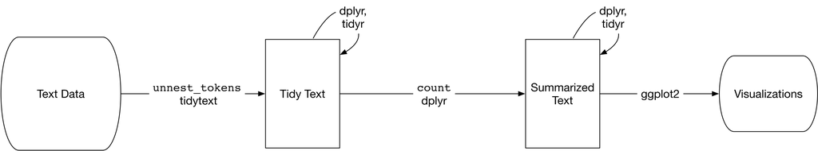

Dieser Text-Mining-Prozess wird im Folgenden schrittweise ergänzt.

## 2.2 Sentimentanalyse

Eine Sentimentanalyse (auch Stimmungsanalyse) ist eine spezielle Ausprägung des Text-Minings. Beim Text-Mining werden Daten in Form von Text mit verschiedenen quantitativen und qualitativen Methoden analysiert. Handelt es sich bei den Textdaten um natürliche Sprache, also durch Menschen formulierte und ausgedrückte Texte, spricht man von *Natural Language Processing* (NLP). Weiternoch geht es beim NLP um die Verarbeitung dieser Textdaten und vor allem um deren Interpretation. Die Interpretation kann bspw. durch die Aufnahme von Stimmen (gesprochene Sprache) und anschließende Übersetzung in textuelle Bausteine erfolgen. Interpretation kann außerdem eine Übersetzung von Stimm- oder Textdaten in eine gewisse Semantik dieser Daten bedeuten.

Sentimentanalyse ist das Feststellen der Stimmung bzw. der Polarität eines Textes und wird auch *Opinion Mining* genannt.

> Die Stimmungsanalyse ist eines der Felder der Natural Language Processing, das sich der Erforschung subjektiver Meinungen oder Gefühle widmet, die aus verschiedenen Quellen zu einem bestimmten Thema gesammelt wurden.  
> — Volodymyr Bilyk

- die Fragestellungen
- der Konzeption der Durchführung
- Auswahl der richtigen Methoden u. Vorgehensweisen
- Reduktion des Problems bzw. der komplexität auf das Wesentliche
- die Interpretaton der Ergebnisse
- Transfer der Ergebnisse aus den Methoden der Sentimentanalyse in weiterführende Methoden

Referenz: https://theappsolutions.com/blog/development/sentiment-analysis/